# 03_convolution_deconvolution

## Convolution & Deconvolution on "Istanbul'u Dinliyorum"

[figure not shown]

```python
from IPython.display import Image, display

display(Image(filename="../data/figures/istanbul_hagia_sophia.jpg", embed=True))
```

*Figure: View of Hagia Sophia. Originally constructed as a church and later transformed into a museum, now functions as an active mosque. Beyond its status as an architectural and historical landmark of the Turkish Republic, it contributes to Istanbul’s layered urban soundscape, shaped by the many mosques across the city. The ezan, or call to prayer, propagates through this environment as a complex acoustic signal: often loud, overlapping and partially obscured, it becomes intelligible only to the attentive listener who filters and reconstructs its structure from the surrounding noise. — © unsplashed.com/@ibuzn.*

## Context

This notebook extends the analysis of *Istanbul'u Dinliyorum* by Sema and Taksim into the domain of linear filtering and signal restoration. The previous sections established sampling fidelity and structural pattern detection; this section addresses a different practical question: what happens when a culturally significant recording is deliberately smoothed to reduce unwanted noise and whether the resulting information loss can be reversed.

Convolution with a smoothing kernel is one of the most fundamental operations in signal processing, applicable across domains from audio restoration to seismology. In this notebook it is applied to a musical recording from Turkiye, where the trade-off between noise suppression and spectral detail preservation directly affects the perceptual quality of the audio. Deconvolution is then explored as the inverse operation, testing whether the original signal characteristics can be recovered from the filtered version.

### Data Source

> Sema & Taksim. "Istanbul'u Dinliyorum." *Hommage an Istanbul*. Network Medien, 1997. CD (Catalogue No. 32.858). Audio sourced from YouTube: https://youtu.be/6RhsJDv3IOU. Converted to mono 44.1 kHz WAV for analysis.

The full project repository can be accessed via https://github.com/shahatem/gbsv

## Use Case

A cultural music archive in Turkiye is digitizing historically and artistically significant recordings for long-term preservation and public access. Some recordings, including field recordings and early studio material, contain broadband environmental noise that reduces listening quality. Convolution with a smoothing kernel offers a straightforward approach to suppress high-frequency noise and improve perceptual clarity. However, smoothing inevitably attenuates transient attacks and harmonic overtones that define the timbre and character of the music - qualities that are essential for faithful archival representation.

## Problem Statement

Audio signals contain frequency components across a broad spectrum and smoothing by convolution acts as a low-pass filter that suppresses high-frequency content indiscriminately. The risk is twofold: insufficient smoothing leaves perceptible noise, while excessive smoothing dulls the musical texture beyond acceptable limits. If the filtering parameters are known, deconvolution can in principle reverse the smoothing and recover the original spectral detail. In practice, however, deconvolution is sensitive to noise, regularization choices and kernel characteristics. The central question is whether Wiener deconvolution can meaningfully restore the original signal from its smoothed version and how reconstruction quality depends on kernel type, kernel size and regularization strength.

## Objective

The objective is threefold. First, I implement one-dimensional convolution manually and verify it against a library reference. Second, I apply Wiener deconvolution to the smoothed signal and assess reconstruction quality. Third, I systematically evaluate how kernel choice, smoothing strength and regularization influence the trade-off between noise suppression and signal restoration fidelity.

## Signal Definition

The signal is the same mono audio excerpt from *Istanbul'u Dinliyorum* used throughout this project, sampled at 44.1 kHz. The excerpt starts at 298 s and spans 4 s, capturing a musically active passage with vocal and instrumental content. For the convolution and deconvolution experiments, I add controlled Gaussian noise to simulate a degraded recording. The analysis operates directly on the waveform samples, rather than on a derived representation such as the RMS envelope.

```python
from pathlib import Path
import sys

import matplotlib.pyplot as plt
import numpy as np
import pandas as pd
from IPython.display import Audio, Markdown, display


def find_project_root() -> Path:
    for candidate in [Path.cwd(), *Path.cwd().parents]:
        if (candidate / "src").exists() and (candidate / "data").exists():
            return candidate
    raise FileNotFoundError("Could not locate the mc1_signals project root.")


PROJECT_ROOT = find_project_root()
if str(PROJECT_ROOT / "src") not in sys.path:
    sys.path.insert(0, str(PROJECT_ROOT / "src"))

from audio_utils import load_audio_mono, peak_normalize, save_audio, to_time_axis
from metrics_utils import normalized_rmse, snr_db, spectral_cosine_similarity
from plotting_utils import save_figure, set_plot_style
from signal_utils import (
    gaussian_kernel,
    manual_convolve_1d,
    moving_average_kernel,
    wiener_deconvolution_1d,
    zscore,
)

set_plot_style()
plt.rcParams["figure.figsize"] = (12, 4)
plt.rcParams["axes.spines.top"] = False
plt.rcParams["axes.spines.right"] = False

DATA_PATH = PROJECT_ROOT / "data" / "raw" / "istanbul_dinliyorum.wav"
OUTPUT_AUDIO = PROJECT_ROOT / "outputs" / "audio"
OUTPUT_FIGURES = PROJECT_ROOT / "outputs" / "figures"
OUTPUT_TABLES = PROJECT_ROOT / "outputs" / "tables"
```

## Methodological Choices

For this analysis, I selected two convolution kernels that represent different smoothing philosophies.

- **Moving average (uniform weights)**: I use this as a baseline because it is the simplest possible smoother. Each sample is replaced by the average of its neighbors, meaning all points within the window contribute equally. This makes it easy to interpret, but it also removes certain frequencies quite aggressively instead of reducing them gradually.
- **Gaussian kernel (bell-shaped weights)**: In contrast, I assign more weight to samples near the center of the window and less to those at the edges. This leads to a smoother and more natural attenuation of high frequencies, without the abrupt removals seen in the moving average. For audio signals, this behavior is generally more desirable.

To study the effect of smoothing strength, I test three kernel sizes: 11, 21 and 31 samples.

- **Odd lengths**: I deliberately choose odd-sized kernels so that each has a clear center and remains symmetric. This ensures that the smoothing does not shift the signal in time. Instead, it only spreads features slightly, which is important when comparing original and processed waveforms.
- **Time extent at 44.1 kHz**: The window durations are very short, given by $T = N / f_s$
  - 11 → 0.25ms
  - 21 → 0.48ms
  - 31 → 0.70ms

  These durations are much shorter than typical musical events. Therefore, I am not altering the overall structure of the signal, but rather smoothing very fine, within-cycle details such as sharp transitions or high-frequency components.
- **Frequency-domain scale (moving-average baseline)**: Each kernel size corresponds to a different level of high-frequency removal.
  - 11 → affects frequencies around 4.0kHz and above
  - 21 → affects frequencies around 2.1kHz and above
  - 31 → affects frequencies around 1.4kHz and above

  Increasing the kernel size therefore increases the smoothing strength. The Gaussian kernels follow the same general scaling, but reduce frequencies more gradually, without sharp cutoffs.
- **Design of the sweep**: I space the kernel sizes evenly to create a controlled progression in smoothing strength. This allows me to isolate how increasing the window size affects the signal, while keeping all other factors constant.

For reconstructing the signal (deconvolution), I choose Wiener filtering instead of simple inverse filtering.

Inverse filtering attempts to fully undo the smoothing, but this tends to amplify noise significantly, especially in frequency regions where the kernel suppresses information.

Wiener filtering introduces a regularization parameter $\lambda$, which balances reconstruction quality and stability. Instead of blindly inverting everything, it limits how much noise can be amplified.

- small $\lambda$: prioritizes accurate reconstruction, but risks amplifying noise
- large $\lambda$: produces a more stable result, but with reduced sharpness

I evaluate $\lambda$ values of 1e-4, 1e-3, 1e-2 and 1e-1 to systematically explore this trade-off.

## Expected Behaviour

Based on these methodological choices, I expect the following outcomes:

- **Convolution**: I expect the smoothing step to reduce high-frequency noise and make the signal perceptibly smoother. As the kernel size increases, the smoothing effect should become stronger, but this will also lead to more attenuation of sharp features such as transients. Comparing the two kernels, I expect the Gaussian kernel to produce a more gradual frequency reduction than the moving average, which should result in less distortion for similar kernel sizes.
- **Deconvolution**: When applying Wiener filtering, I expect to recover part of the original spectral content from the smoothed signal. With low regularization (small $\lambda$), the reconstruction should be closer to the original signal, but more sensitive to noise. With higher regularization (large $\lambda$), the result should be more stable, although some of the smoothing effect will remain. I also expect reconstruction quality to decrease as the kernel size increases, since stronger smoothing removes more information that cannot be perfectly recovered.
- **Metrics**: The evaluation metrics should reflect these trade-offs. I expect the NRMSE between the original and reconstructed signal to decrease when reconstruction improves. The SNR should increase after smoothing, since noise is reduced, but may decrease again after deconvolution due to noise amplification. Spectral cosine similarity should be highest for the reconstruction that best preserves the original frequency content.

### Baseline Configuration

Before running the full parameter sweep, a single reference configuration is used to visualize the kernels, verify the convolution implementation and illustrate the deconvolution pipeline end-to-end. I fix the kernel size at 21 samples and the regularization at λ = 1e-3 for this purpose. The systematic variation across all kernel sizes, λ values and noise levels follows in the Parameter Sensitivity Study below.

```python
config = {
    "excerpt_start_sec": 298,
    "excerpt_duration_sec": 4,
    "reference_sr": 44100,
    "kernel_size": 21,
    "gaussian_sigma": 3.5,
    "noise_std": 0.02,
    "wiener_lambda": 1e-3,
}

original, sr = load_audio_mono(
    DATA_PATH,
    target_sr=config["reference_sr"],
    start_sec=config["excerpt_start_sec"],
    duration_sec=config["excerpt_duration_sec"],
)
original = peak_normalize(original)
time_axis = to_time_axis(len(original), sr)

rng = np.random.default_rng(42)
noise = rng.normal(0, config["noise_std"], size=len(original)).astype(np.float32)
noisy = original + noise

display(Markdown("**Original excerpt (clean)**"))
display(Audio(original, rate=sr, embed=True))
display(Markdown("**Degraded excerpt (with simulated noise)**"))
display(Audio(noisy, rate=sr, embed=True))

metadata = pd.DataFrame(
    [
        ("excerpt_start_sec", config["excerpt_start_sec"]),
        ("excerpt_duration_sec", config["excerpt_duration_sec"]),
        ("reference_sr", config["reference_sr"]),
        ("kernel_size", config["kernel_size"]),
        ("gaussian_sigma", config["gaussian_sigma"]),
        ("noise_std", config["noise_std"]),
        ("wiener_lambda", config["wiener_lambda"]),
    ],
    columns=["parameter", "value"],
)
metadata
```

**Original excerpt (clean)**

[interactive chart not shown]

**Degraded excerpt (with simulated noise)**

[interactive chart not shown]

|  | parameter | value |
| --- | --- | --- |
| 0 | excerpt_start_sec | 298.000 |
| 1 | excerpt_duration_sec | 4.000 |
| 2 | reference_sr | 44100.000 |
| 3 | kernel_size | 21.000 |
| 4 | gaussian_sigma | 3.500 |
| 5 | noise_std | 0.020 |
| 6 | wiener_lambda | 0.001 |

### Kernel Visualization

Before applying convolution, the two selected kernels are visualized to confirm their shape and normalization. The moving average kernel has uniform weights that sum to one; the Gaussian kernel has a bell-shaped profile centered in the window.

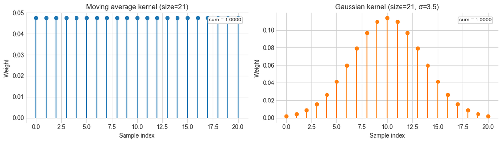

```python
ma_kernel = moving_average_kernel(config["kernel_size"])
gauss_kernel = gaussian_kernel(config["kernel_size"], sigma=config["gaussian_sigma"])

fig, axes = plt.subplots(1, 2, figsize=(12, 3.5))

axes[0].stem(np.arange(len(ma_kernel)), ma_kernel, basefmt=" ", linefmt="tab:blue", markerfmt="o")
axes[0].set_title(f"Moving average kernel (size={config['kernel_size']})")
axes[0].set_xlabel("Sample index")
axes[0].set_ylabel("Weight")
axes[0].text(
    0.97, 0.92, f"sum = {ma_kernel.sum():.4f}",
    transform=axes[0].transAxes, ha="right", fontsize=9,
    bbox=dict(boxstyle="round,pad=0.2", fc="white", ec="0.8"),
)

axes[1].stem(np.arange(len(gauss_kernel)), gauss_kernel, basefmt=" ", linefmt="tab:orange", markerfmt="o")
axes[1].set_title(f"Gaussian kernel (size={config['kernel_size']}, σ={config['gaussian_sigma']})")
axes[1].set_xlabel("Sample index")
axes[1].set_ylabel("Weight")
axes[1].text(
    0.97, 0.92, f"sum = {gauss_kernel.sum():.4f}",
    transform=axes[1].transAxes, ha="right", fontsize=9,
    bbox=dict(boxstyle="round,pad=0.2", fc="white", ec="0.8"),
)

plt.tight_layout()
save_figure(fig, OUTPUT_FIGURES / "03_kernels.png")
plt.show()
```

### Manual Convolution And Verification

The convolution is implemented manually as a sliding-window dot product in the spatial domain (see `manual_convolve_1d` in `signal_utils.py`). The implementation iterates over each output position, multiplies overlapping signal and flipped-kernel values and sums the products. Boundary handling uses implicit zero-padding via index checks and the `mode="same"` option returns an output of the same length as the input.

To verify correctness, the manual result is compared element-wise against `numpy.convolve`. The maximum absolute difference should be near machine precision for float32 arithmetic.

**Verification:** manual vs. `numpy.convolve`

- Max absolute difference: 1.79e-07

- Mean absolute difference: 1.11e-08

Both values are near float32 precision, confirming that `manual_convolve_1d` is correct.

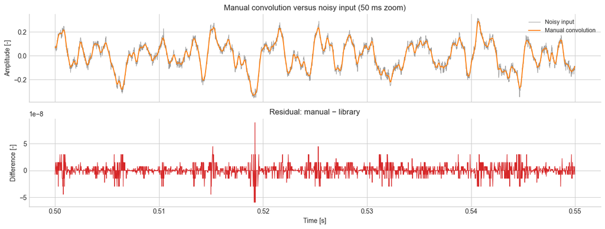

```python
filtered_manual = manual_convolve_1d(noisy, gauss_kernel, mode="same")
filtered_library = np.convolve(noisy, gauss_kernel, mode="same").astype(np.float32)

max_diff = float(np.max(np.abs(filtered_manual - filtered_library)))
mean_diff = float(np.mean(np.abs(filtered_manual - filtered_library)))

display(Markdown(
    f"**Verification:** manual vs. `numpy.convolve`\n\n"
    f"- Max absolute difference: {max_diff:.2e}\n"
    f"- Mean absolute difference: {mean_diff:.2e}\n\n"
    f"Both values are near float32 precision, confirming that `manual_convolve_1d` is correct."
))

zoom_start, zoom_end = int(0.5 * sr), int(0.55 * sr)

fig, axes = plt.subplots(2, 1, figsize=(13, 5), sharex=True)
axes[0].plot(time_axis[zoom_start:zoom_end], noisy[zoom_start:zoom_end], color="0.6", linewidth=0.7, label="Noisy input")
axes[0].plot(time_axis[zoom_start:zoom_end], filtered_manual[zoom_start:zoom_end], color="tab:orange", linewidth=1.4, label="Manual convolution")
axes[0].set_title("Manual convolution versus noisy input (50 ms zoom)")
axes[0].set_ylabel("Amplitude [-]")
axes[0].legend(loc="upper right", fontsize=9)

residual = filtered_manual[zoom_start:zoom_end] - filtered_library[zoom_start:zoom_end]
axes[1].plot(time_axis[zoom_start:zoom_end], residual, color="tab:red", linewidth=0.8)
axes[1].set_title("Residual: manual − library")
axes[1].set_xlabel("Time [s]")
axes[1].set_ylabel("Difference [-]")
axes[1].ticklabel_format(axis="y", style="scientific", scilimits=(-2, 2))

plt.tight_layout()
save_figure(fig, OUTPUT_FIGURES / "03_convolution_verification.png")
plt.show()
```

#### Convolution Observations

The manual implementation produces results that match `numpy.convolve` to within float32 rounding tolerance. The upper panel shows that the Gaussian-convolved signal follows the noisy input but with visibly reduced high-frequency fluctuations, consistent with the low-pass character of the kernel. The residual panel confirms numerical agreement between the two implementations.

### Deconvolution

With the convolution verified, the next step applies Wiener deconvolution to the filtered signal to test whether the original waveform can be recovered. The Wiener filter operates in the frequency domain: it divides the observed spectrum by the kernel spectrum, regularized by λ to prevent division by near-zero values. The result should approximate the pre-convolution signal, with reconstruction quality depending on the regularization strength.

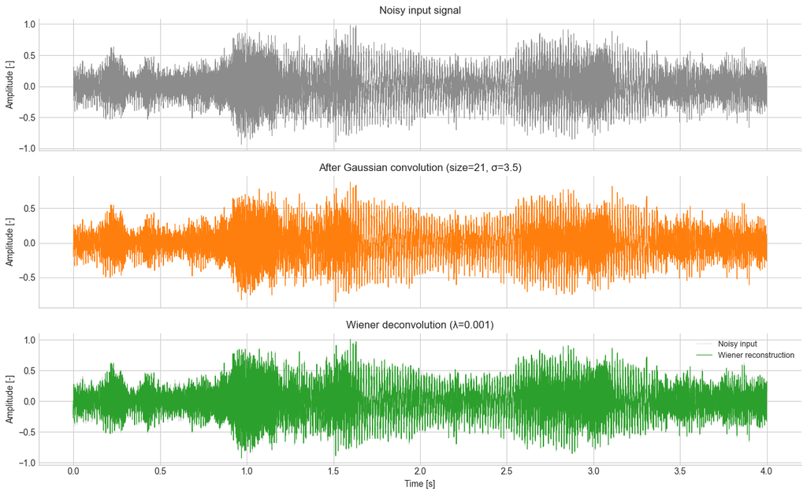

```python
reconstructed = wiener_deconvolution_1d(filtered_manual, gauss_kernel, lam=config["wiener_lambda"])

fig, axes = plt.subplots(3, 1, figsize=(13, 8), sharex=True)

axes[0].plot(time_axis, noisy, color="0.55", linewidth=0.5)
axes[0].set_title("Noisy input signal")
axes[0].set_ylabel("Amplitude [-]")

axes[1].plot(time_axis, filtered_manual, color="tab:orange", linewidth=0.8)
axes[1].set_title(f"After Gaussian convolution (size={config['kernel_size']}, σ={config['gaussian_sigma']})")
axes[1].set_ylabel("Amplitude [-]")

axes[2].plot(time_axis, noisy, color="0.8", linewidth=0.4, label="Noisy input")
axes[2].plot(time_axis, reconstructed, color="tab:green", linewidth=0.8, label="Wiener reconstruction")
axes[2].set_title(f"Wiener deconvolution (λ={config['wiener_lambda']})")
axes[2].set_xlabel("Time [s]")
axes[2].set_ylabel("Amplitude [-]")
axes[2].legend(loc="upper right", fontsize=9)

plt.tight_layout()
save_figure(fig, OUTPUT_FIGURES / "03_convolution_deconvolution_comparison.png")
plt.show()
```

```python
display(Markdown("**Filtered signal (after Gaussian convolution)**"))
display(Audio(filtered_manual, rate=sr, embed=True))

display(Markdown("**Reconstructed signal (after Wiener deconvolution)**"))
display(Audio(reconstructed, rate=sr, embed=True))
```

**Filtered signal (after Gaussian convolution)**

[interactive chart not shown]

**Reconstructed signal (after Wiener deconvolution)**

[interactive chart not shown]

#### Deconvolution Observations

The three-panel comparison shows the progression from noisy input through smoothing to reconstruction. The filtered signal visibly suppresses high-frequency noise but also rounds off waveform transients. The Wiener reconstruction recovers much of the original waveform shape, though close inspection reveals minor amplitude differences and residual smoothing, particularly where the kernel strongly attenuated high-frequency content.

### Quantitative Evaluation

To move beyond visual inspection, three metrics are computed for the baseline configuration to quantify filtering and reconstruction quality:

- **NRMSE** (Normalized Root Mean Squared Error): measures overall waveform deviation relative to the original signal energy. Lower is better.
- **SNR** (Signal-to-Noise Ratio in dB): measures how much signal power exceeds residual error power. Higher is better.
- **Spectral Cosine Similarity**: measures alignment of frequency magnitude distributions between two signals. Values near 1.0 indicate well-preserved spectral shape.

Each metric is computed for the noisy input, the filtered signal and the reconstructed signal, all measured against the clean original as the reference.

|  | signal | nrmse | snr_db | spectral_cosine |
| --- | --- | --- | --- | --- |
| 0 | noisy (degraded) | 0.0866 | 21.25 | 0.9974 |
| 1 | filtered (convolved) | 0.1272 | 17.91 | 0.9927 |
| 2 | reconstructed (deconvolved) | 0.0554 | 25.14 | 0.9989 |

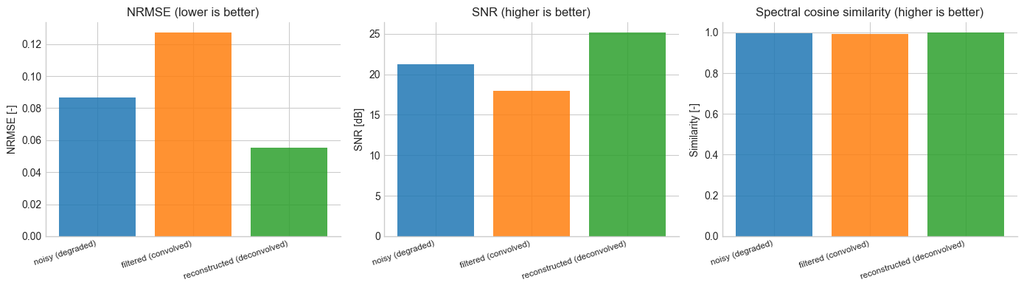

```python
n = min(len(original), len(filtered_manual), len(reconstructed))
orig_trim = original[:n]
noisy_trim = noisy[:n]
filt_trim = filtered_manual[:n]
recon_trim = reconstructed[:n]

baseline_metrics = pd.DataFrame([
    {
        "signal": "noisy (degraded)",
        "nrmse": normalized_rmse(orig_trim, noisy_trim),
        "snr_db": snr_db(orig_trim, noisy_trim),
        "spectral_cosine": spectral_cosine_similarity(orig_trim, noisy_trim),
    },
    {
        "signal": "filtered (convolved)",
        "nrmse": normalized_rmse(orig_trim, filt_trim),
        "snr_db": snr_db(orig_trim, filt_trim),
        "spectral_cosine": spectral_cosine_similarity(orig_trim, filt_trim),
    },
    {
        "signal": "reconstructed (deconvolved)",
        "nrmse": normalized_rmse(orig_trim, recon_trim),
        "snr_db": snr_db(orig_trim, recon_trim),
        "spectral_cosine": spectral_cosine_similarity(orig_trim, recon_trim),
    },
])
baseline_metrics.to_csv(OUTPUT_TABLES / "03_baseline_metrics.csv", index=False)

display(baseline_metrics.style.format({
    "nrmse": "{:.4f}", "snr_db": "{:.2f}", "spectral_cosine": "{:.4f}"
}))

fig, axes = plt.subplots(1, 3, figsize=(14, 4))
labels = baseline_metrics["signal"].tolist()
colors = ["tab:blue", "tab:orange", "tab:green"]
x = np.arange(len(labels))

axes[0].bar(x, baseline_metrics["nrmse"], color=colors, alpha=0.85)
axes[0].set_xticks(x, labels, rotation=18, ha="right", fontsize=8.5)
axes[0].set_title("NRMSE (lower is better)")
axes[0].set_ylabel("NRMSE [-]")

axes[1].bar(x, baseline_metrics["snr_db"], color=colors, alpha=0.85)
axes[1].set_xticks(x, labels, rotation=18, ha="right", fontsize=8.5)
axes[1].set_title("SNR (higher is better)")
axes[1].set_ylabel("SNR [dB]")

axes[2].bar(x, baseline_metrics["spectral_cosine"], color=colors, alpha=0.85)
axes[2].set_xticks(x, labels, rotation=18, ha="right", fontsize=8.5)
axes[2].set_title("Spectral cosine similarity (higher is better)")
axes[2].set_ylabel("Similarity [-]")

plt.tight_layout()
save_figure(fig, OUTPUT_FIGURES / "03_baseline_metrics.png")
plt.show()
```

### Parameter Sensitivity Study

To evaluate robustness and map trade-offs beyond the baseline, four parameters are systematically varied:

- **Kernel type**: moving average vs. Gaussian
- **Kernel size**: 11, 21, 31 samples
- **Regularization λ**: 1e-4, 1e-3, 1e-2, 1e-1
- **Noise level**: 0.0 (clean), 0.02 (moderate), 0.05 (strong)

For each combination, convolution is applied using `numpy.convolve` (verified equivalent to the manual implementation), followed by Wiener deconvolution. All three metrics are computed against the clean original. This produces a structured comparison of 72 configurations that isolates the effect of each parameter on filtering and reconstruction performance.

```python
rng = np.random.default_rng(42)
kernel_sizes = [11, 21, 31]
lambda_values = [1e-4, 1e-3, 1e-2, 1e-1]
noise_levels = [0.0, 0.02, 0.05]

sweep_rows = []
for k_size in kernel_sizes:
    ma_k = moving_average_kernel(k_size)
    sigma = k_size / 6.0
    ga_k = gaussian_kernel(k_size, sigma=sigma)

    for noise_std in noise_levels:
        if noise_std > 0:
            noisy_variant = original + rng.normal(0, noise_std, size=len(original)).astype(np.float32)
        else:
            noisy_variant = original.copy()

        for kernel_name, kernel in [("moving_average", ma_k), ("gaussian", ga_k)]:
            filtered = np.convolve(noisy_variant, kernel, mode="same").astype(np.float32)
            n_common = min(len(original), len(filtered))

            for lam in lambda_values:
                recon = wiener_deconvolution_1d(filtered, kernel, lam=lam)
                n_all = min(n_common, len(recon))
                o, f, r = original[:n_all], filtered[:n_all], recon[:n_all]

                sweep_rows.append({
                    "kernel": kernel_name,
                    "kernel_size": k_size,
                    "noise_std": noise_std,
                    "lambda": lam,
                    "filt_nrmse": normalized_rmse(o, f),
                    "filt_snr_db": snr_db(o, f),
                    "filt_spectral_cos": spectral_cosine_similarity(o, f),
                    "recon_nrmse": normalized_rmse(o, r),
                    "recon_snr_db": snr_db(o, r),
                    "recon_spectral_cos": spectral_cosine_similarity(o, r),
                })

sweep_df = pd.DataFrame(sweep_rows)
sweep_df.to_csv(OUTPUT_TABLES / "03_parameter_sweep.csv", index=False)
sweep_df.head(10)
```

|  | kernel | kernel_size | noise_std | lambda | filt_nrmse | filt_snr_db | filt_spectral_cos | recon_nrmse | recon_snr_db | recon_spectral_cos |
| --- | --- | --- | --- | --- | --- | --- | --- | --- | --- | --- |
| 0 | moving_average | 11 | 0.00 | 0.0001 | 0.129492 | 17.755114 | 0.992698 | 0.026327 | 31.592093 | 0.999745 |
| 1 | moving_average | 11 | 0.00 | 0.0010 | 0.129492 | 17.755114 | 0.992698 | 0.041205 | 27.701025 | 0.999183 |
| 2 | moving_average | 11 | 0.00 | 0.0100 | 0.129492 | 17.755114 | 0.992698 | 0.065838 | 23.630516 | 0.997921 |
| 3 | moving_average | 11 | 0.00 | 0.1000 | 0.129492 | 17.755114 | 0.992698 | 0.139438 | 17.112379 | 0.995163 |
| 4 | gaussian | 11 | 0.00 | 0.0001 | 0.057433 | 24.816782 | 0.998442 | 0.015478 | 36.205727 | 0.999959 |
| 5 | gaussian | 11 | 0.00 | 0.0010 | 0.057433 | 24.816782 | 0.998442 | 0.013211 | 37.581524 | 0.999934 |
| 6 | gaussian | 11 | 0.00 | 0.0100 | 0.057433 | 24.816782 | 0.998442 | 0.021956 | 33.168865 | 0.999818 |
| 7 | gaussian | 11 | 0.00 | 0.1000 | 0.057433 | 24.816782 | 0.998442 | 0.099761 | 20.020786 | 0.999460 |
| 8 | moving_average | 11 | 0.02 | 0.0001 | 0.132268 | 17.570917 | 0.992610 | 0.086138 | 21.296137 | 0.997475 |
| 9 | moving_average | 11 | 0.02 | 0.0010 | 0.132268 | 17.570917 | 0.992610 | 0.082994 | 21.619114 | 0.997558 |

### Robustness Assessment

The left panel shows reconstruction NRMSE as a function of kernel size for both kernel types under moderate noise, selecting the best regularization λ for each configuration. The right panel shows how reconstruction SNR depends on λ at a fixed kernel size, illustrating the stability–fidelity trade-off for both kernel types.

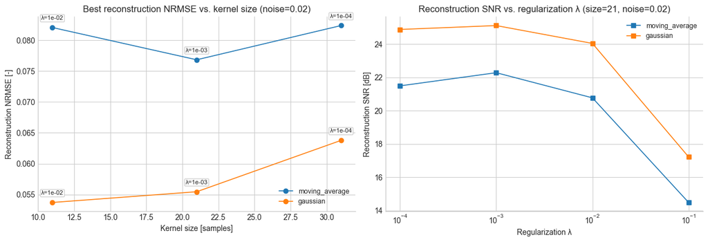

|  | kernel | kernel_size | lambda | recon_nrmse | recon_snr_db | recon_spectral_cos |
| --- | --- | --- | --- | --- | --- | --- |
| 14 | gaussian | 11 | 1e-02 | 0.0537 | 25.40 | 0.9993 |
| 37 | gaussian | 21 | 1e-03 | 0.0554 | 25.12 | 0.9989 |
| 36 | gaussian | 21 | 1e-04 | 0.0570 | 24.89 | 0.9991 |
| 13 | gaussian | 11 | 1e-03 | 0.0575 | 24.80 | 0.9992 |
| 38 | gaussian | 21 | 1e-02 | 0.0627 | 24.05 | 0.9985 |

**Best by reconstruction error (NRMSE):** gaussian, size=11, λ=1e-02 → NRMSE=0.0537, SNR=25.40 dB.

**Best by reconstruction SNR:** gaussian, size=11, λ=1e-02 → NRMSE=0.0537, SNR=25.40 dB.

```python
moderate = sweep_df.query("noise_std == 0.02").copy()

fig, axes = plt.subplots(1, 2, figsize=(13, 4.5))

for kernel_name in ["moving_average", "gaussian"]:
    subset = moderate[moderate["kernel"] == kernel_name]
    best_per_size = subset.loc[subset.groupby("kernel_size")["recon_nrmse"].idxmin()]
    axes[0].plot(
        best_per_size["kernel_size"], best_per_size["recon_nrmse"],
        marker="o", linewidth=1.2, label=kernel_name,
    )
    for _, row in best_per_size.iterrows():
        axes[0].annotate(
            f"λ={row['lambda']:.0e}",
            xy=(row["kernel_size"], row["recon_nrmse"]),
            xytext=(0, 10), textcoords="offset points", ha="center", fontsize=8,
            bbox=dict(boxstyle="round,pad=0.15", fc="white", ec="0.8", alpha=0.9),
        )

axes[0].set_title("Best reconstruction NRMSE vs. kernel size (noise=0.02)")
axes[0].set_xlabel("Kernel size [samples]")
axes[0].set_ylabel("Reconstruction NRMSE [-]")
axes[0].legend(fontsize=9)

fixed_size = moderate.query("kernel_size == 21").copy()
for kernel_name in ["moving_average", "gaussian"]:
    subset = fixed_size[fixed_size["kernel"] == kernel_name].sort_values("lambda")
    axes[1].plot(
        subset["lambda"], subset["recon_snr_db"],
        marker="s", linewidth=1.2, label=kernel_name,
    )

axes[1].set_xscale("log")
axes[1].set_title("Reconstruction SNR vs. regularization λ (size=21, noise=0.02)")
axes[1].set_xlabel("Regularization λ")
axes[1].set_ylabel("Reconstruction SNR [dB]")
axes[1].legend(fontsize=9)

plt.tight_layout()
save_figure(fig, OUTPUT_FIGURES / "03_parameter_summary.png")
plt.show()

best_configs = moderate.sort_values("recon_nrmse").head(5)
display(best_configs[[
    "kernel", "kernel_size", "lambda",
    "recon_nrmse", "recon_snr_db", "recon_spectral_cos",
]].style.format({
    "lambda": "{:.0e}",
    "recon_nrmse": "{:.4f}",
    "recon_snr_db": "{:.2f}",
    "recon_spectral_cos": "{:.4f}",
}))

best_by_nrmse = best_configs.iloc[0]
best_by_snr = moderate.sort_values("recon_snr_db", ascending=False).iloc[0]
display(Markdown(
    f"**Best by reconstruction error (NRMSE):** {best_by_nrmse['kernel']}, "
    f"size={int(best_by_nrmse['kernel_size'])}, λ={best_by_nrmse['lambda']:.0e} "
    f"→ NRMSE={best_by_nrmse['recon_nrmse']:.4f}, SNR={best_by_nrmse['recon_snr_db']:.2f} dB.\n\n"
    f"**Best by reconstruction SNR:** {best_by_snr['kernel']}, "
    f"size={int(best_by_snr['kernel_size'])}, λ={best_by_snr['lambda']:.0e} "
    f"→ NRMSE={best_by_snr['recon_nrmse']:.4f}, SNR={best_by_snr['recon_snr_db']:.2f} dB."
))
```

#### Parameter Study Observations

The λ–SNR panel reveals the stability–fidelity trade-off directly: very small λ values maximize fidelity but risk noise amplification, while large λ values stabilize reconstruction at the cost of retained smoothing. The optimal λ depends on the noise level and kernel characteristics. Under moderate noise, an intermediate regularization (around 1e-3 to 1e-2) balances these competing demands.

## Evaluation And Discussion

The convolution–deconvolution pipeline applied to *Istanbul'u Dinliyorum* addresses a concrete preservation scenario: smoothing a noise-degraded recording and then testing whether the original spectral detail can be recovered. The manual convolution implementation matches `numpy.convolve` to float32 precision, confirming correctness.

These results show that convolution is effective for controlled noise reduction, but deconvolution is not a lossless inverse: it is useful when filtering parameters are known and noise is moderate, but it introduces its own artifacts when pushed beyond its stable operating range.

## Conclusion And Reflection

This notebook closes the three-part signal processing analysis of *Istanbul'u Dinliyorum*. Across sampling, correlation and convolution, the same recording served as a consistent testbed for progressively different technical questions. The convolution section showed that even a simple linear operation involves meaningful design choices — kernel shape and size are not neutral parameters — and that deconvolution, while theoretically elegant, is practically constrained by noise and regularization.

The most valuable insight from MC1 overall is that signal processing methods are not standalone: their effectiveness depends on how the signal is represented, what assumptions are made and how parameters are chosen. Each notebook required not just implementation but interpretation — deciding what counts as a meaningful result and where the method reaches its limits. If I were to repeat this work, I would spend more time on systematic sensitivity analysis earlier in the process, as the parameter studies consistently revealed trade-offs that single-configuration results could not show.